# Homework 2 Report

## Name

Arjun Amitabh Kumar

### Setup

Read in the data with `read_csv()` and store the data as an R object named `dataset`. Check the data to make sure all of the expected observations and variables are there.

```r
library(tidyverse)
```

```r
library(broom)
library(ggplot2)
library(kableExtra)
library(dplyr)
maacs <- read.csv("maacs.csv.gz")
```

## Part 1

We will first consider the relationship between FEV1 and age. In general, it is expected that as children get older (and hence, larger in size), their FEV1 values should get higher.

Consider the statement “FEV1 values in children are higher in older children relative to younger children”.

Write a function in R that takes the `dataset` object as an argument and returns `TRUE` if the statement above is true for the dataset and `FALSE` otherwise.

NOTE: In order to write this function, you will need to translate the statement above into something that can be checked with the data. There are many ways in which you can do that translation correctly and you only need to pick one way here.

NOTE: For this part, do not use any plots.

```r
check_fev1_increases_with_age <- function(d){
  c <- coef(summary(lm(fev1 ~ age, d, na.action = na.omit)))[2,]
  c[1] > 0 && c[4] < .05
}

check_fev1_increases_with_age(maacs)
```

```
## [1] TRUE
```

## Part 2

Fit a linear regression model with FEV1 as the outcome and age as a predictor.

How much does FEV1 change for a 1-year increase in the child’s age?

```r
m <- lm(fev1 ~ age, maacs)
coef(m)["age"]
```

```
##       age
## 0.1711623
```

```r
confint(m)["age", ]
```

```
##     2.5 %    97.5 %
## 0.1494341 0.1928904
```

Each additional year of age is associated with around a 0.171 L increase in FEV1 (95% Confidence Interval: 0.149 to 0.193 L) in this sample, based off linear regression of FEV1 on age.

## Part 3

Develop **three** supporting premises derived from the data that support the statement you wrote in Part 2. These can be plots, other summary statistics, or model results.

NOTE:

- At least one supporting premise should use a plot.
- Do not use the code you write in Part 1 as a supporting premise

```r
# 1) Older vs younger halves: mean FEV1 + t-test
maacs2 <- na.omit(maacs[, c("fev1","age")])
maacs2$grp <- ifelse(maacs2$age <= median(maacs2$age), "younger","older")
aggregate(fev1 ~ grp, maacs2, mean)
```

```
##       grp     fev1
## 1   older 2.605909
## 2 younger 1.391045
```

```r
t.test(fev1 ~ grp, data = maacs2)
```

```
##
##  Welch Two Sample t-test
##
## data:  fev1 by grp
## t = 12.96, df = 111.52, p-value < 2.2e-16
## alternative hypothesis: true difference in means between group older and group younger is not equal to 0
## 95 percent confidence interval:
##  1.029126 1.400603
## sample estimates:
##   mean in group older mean in group younger
##              2.605909              1.391045
```

```r
# 2) Correlation between age and FEV1
cor.test(maacs2$age, maacs2$fev1, method = "pearson")
```

```
##
##  Pearson's product-moment correlation
##
## data:  maacs2$age and maacs2$fev1
## t = 15.583, df = 131, p-value < 2.2e-16
## alternative hypothesis: true correlation is not equal to 0
## 95 percent confidence interval:
##  0.7368348 0.8584229
## sample estimates:
##       cor
## 0.8059696
```

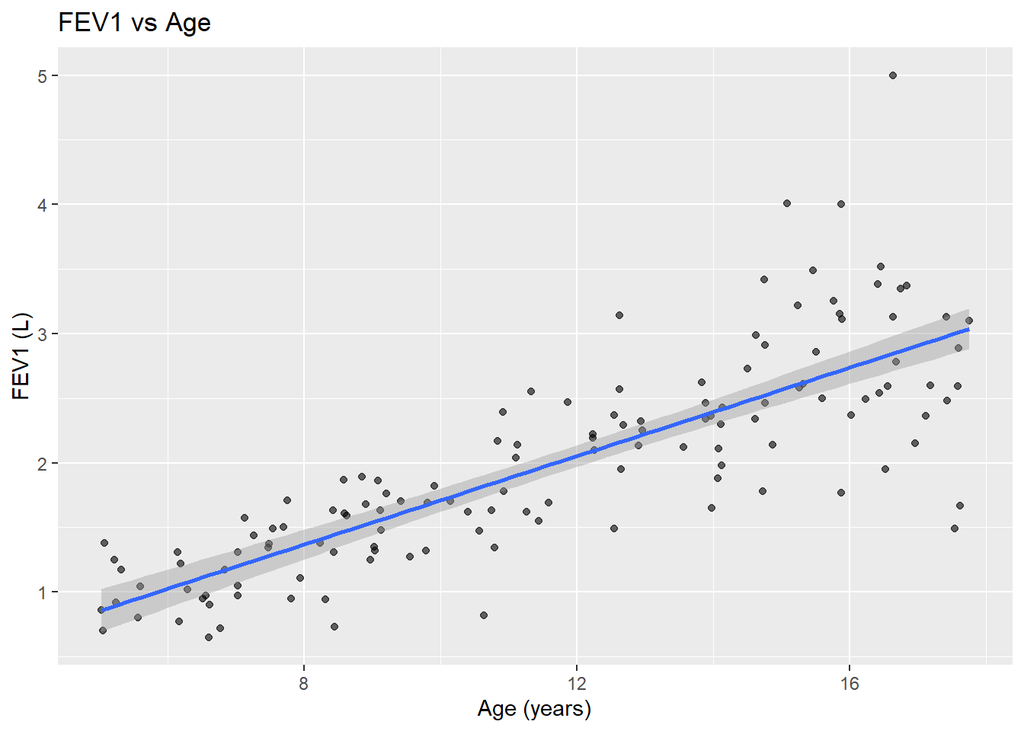

```r
# 3) Plot: FEV1 vs age with fitted line
library(ggplot2)
ggplot(maacs2, aes(age, fev1)) +
  geom_point(alpha = 0.6) +
  geom_smooth(method = "lm", se = TRUE) +
  labs(x = "Age (years)", y = "FEV1 (L)", title = "FEV1 vs Age")
```

1. The older half has a higher average FEV1 than the younger half (2.606 L vs. 1.391). The difference is large and statistically significant (Welch t-value approximately 12.96, and p-value is below 0.0001; 95% CI: 1.03 to 1.40L)
2. Age and FEV1 are strongly positively correlated ( r approximately 0.8, 95% CI: 0.737 to 0.858; t approximately 15.58 with p < 0.001).
3. The scatterplot of FEV1 versus age shows us a clear upwards trend with a positive fitted regression line, underscoring higher FEV1 at older age ranges.

## Part 4

For each of the supporting premises above, write a function that takes the `dataset` object as an argument and returns `TRUE` if the supporting premise statement above is true for the dataset and `FALSE` otherwise.

For statements involving plots, instead of returning `TRUE` or `FALSE`, you function should do two things:

1. Produce the plot that is used in the statement
2. Produce a hypothetical version of the plot in the event that the statement is true. This can be done using simulated data or by simply hand drawing a plot.

```r
# Premise 1
premise1_older_half_higher <- function(dataset){
  d <- na.omit(dataset[, c("fev1","age")])
  g <- ifelse(d$age <= median(d$age), "younger", "older")
  tt <- t.test(d$fev1 ~ g)
  mean(d$fev1[g=="older"]) > mean(d$fev1[g=="younger"]) && tt$p.value < .05
}

premise1_older_half_higher(maacs)
```

```
## [1] TRUE
```

```r
# Premise 2
premise2_pos_corr <- function(dataset){
  d <- na.omit(dataset[, c("fev1","age")])
  ct <- cor.test(d$age, d$fev1, method = "pearson")
  (ct$estimate > 0) && (ct$p.value < .05)
}

premise2_pos_corr(maacs)
```

```
## [1] TRUE
```

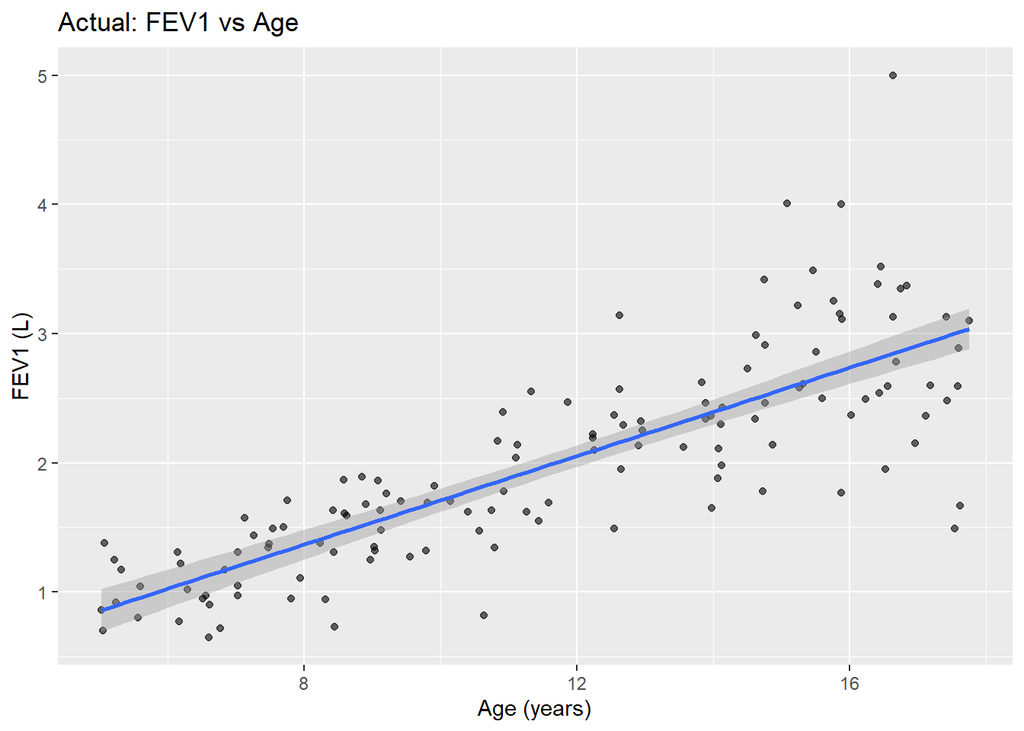

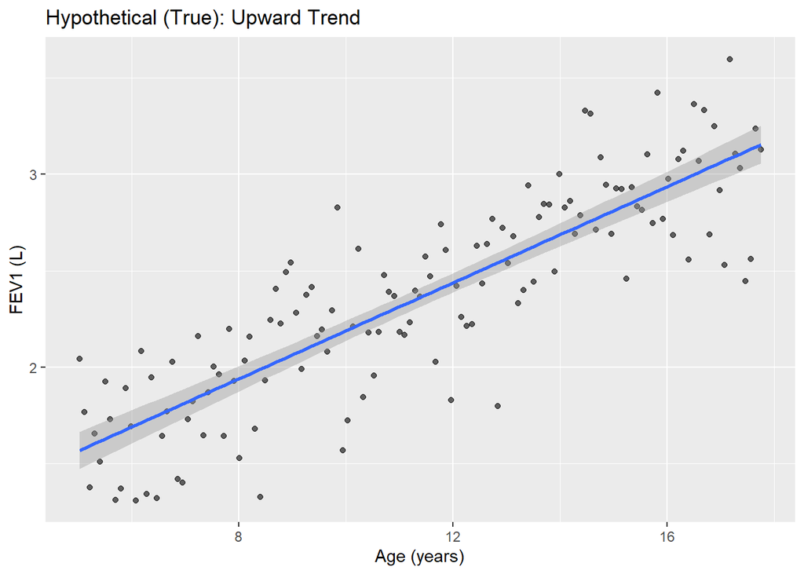

```r
premise3_plot_with_hypo <- function(dataset, seed = 375){
  d <- na.omit(dataset[, c("fev1","age")])
  print(ggplot2::ggplot(d, ggplot2::aes(age, fev1)) +
          ggplot2::geom_point(alpha=.6) +
          ggplot2::geom_smooth(method="lm", se=TRUE) +
          ggplot2::labs(title="Actual: FEV1 vs Age", x="Age (years)", y="FEV1 (L)"))
  set.seed(seed)
  a <- seq(min(d$age), max(d$age), length.out = max(100, nrow(d)))
  y <- 1 + 0.12*a + stats::rnorm(length(a), 0, 0.25)
  s <- data.frame(age=a, fev1=y)
  print(ggplot2::ggplot(s, ggplot2::aes(age, fev1)) +
          ggplot2::geom_point(alpha=.6) +
          ggplot2::geom_smooth(method="lm", se=TRUE) +
          ggplot2::labs(title="Hypothetical (True): Upward Trend", x="Age (years)", y="FEV1 (L)"))
  invisible(NULL)
}

premise3_plot_with_hypo(maacs)
```

Execute each of your function and show that the produce the expected output.

## Part 5

Describe one alternative to the primary statement “FEV1 values in children are higher in older children relative to younger children”.

Create a fault tree for the alternative outcome describing how the alternative outcome could be realized in the data even if the primary statement were true.

Your fault tree should be created as a separate image and does not need to be created in R. Upload the image of the fault tree to Canvas.

```r
dir.create("docs/figs", recursive = TRUE, showWarnings = FALSE)

dot <- "
digraph ft {
  graph [rankdir=TB, splines=ortho, nodesep=0.25, ranksep=0.4]
  node  [shape=box, style=rounded, fontname=Helvetica, fontsize=10, width=2.4]
  edge  [arrowhead=none]
  A [label='Observed: flat/negative age–FEV1']
  B [label='Confounding / Scaling (OR)']
  C [label='Selection / Sampling Bias (OR)']
  D [label='Measurement / Quality (OR)']
  B1 [label='No size/height adjustment']
  B2 [label='Severity/meds differ by age']
  C1 [label='Severe older cases enriched']
  C2 [label='Missing-not-at-random by age']
  D1 [label='Technique/timing differs by age']
  D2 [label='Calibration / unit errors']
  A -> {B C D}
  B -> {B1 B2}
  C -> {C1 C2}
  D -> {D1 D2}
}
"

g <- DiagrammeR::grViz(dot)
svg_txt <- DiagrammeRsvg::export_svg(g)
rsvg::rsvg_png(charToRaw(svg_txt), "docs/figs/fault_tree_depth3.png", width = 800, height = 1100)
```